# Week 7 - Homework

STAT 420, Summer 2020, purohit4@illinois.edu

## Exercise 1 (EPA Emissions Data)

For this exercise, we will use the data stored in `epa2017.csv`. It contains detailed descriptions of vehicles manufactured in 2017 that were used for fuel economy testing [as performed by the Environment Protection Agency](https://www.epa.gov/air-emissions-inventories). The variables in the dataset are:

- `Make` - Manufacturer
- `Model` - Model of vehicle
- `ID` - Manufacturer defined vehicle identification number within EPA’s computer system (not a VIN number)
- `disp` - Cubic inch displacement of test vehicle
- `type` - Car, truck, or both (for vehicles that meet specifications of both car and truck, like smaller SUVs or crossovers)
- `horse` - Rated horsepower, in foot-pounds per second
- `cyl` - Number of cylinders
- `lockup` - Vehicle has transmission lockup; N or Y
- `drive` - Drivetrain system code
  - A = All-wheel drive
  - F = Front-wheel drive
  - P = Part-time 4-wheel drive
  - R = Rear-wheel drive
  - 4 = 4-wheel drive
- `weight` - Test weight, in pounds
- `axleratio` - Axle ratio
- `nvratio` - n/v ratio (engine speed versus vehicle speed at 50 mph)
- `THC` - Total hydrocarbons, in grams per mile (g/mi)
- `CO` - Carbon monoxide (a regulated pollutant), in g/mi
- `CO2` - Carbon dioxide (the primary byproduct of all fossil fuel combustion), in g/mi
- `mpg` - Fuel economy, in miles per gallon

We will attempt to model `CO2` using both `horse` and `type`. In practice, we would use many more predictors, but limiting ourselves to these two, one numeric and one factor, will allow us to create a number of plots.

Load the data, and check its structure using `str()`. Verify that `type` is a factor; if not, coerce it to be a factor.

```r
epa_df <- read.csv("epa2017.csv")
print(paste("Is type a factor = ", is.factor(epa_df$type)))

print("Structure of the epa data set before coercing to factor is as below ")

str(epa_df)

epa_df$type <- as.factor(epa_df$type)

print(paste("Is type a factor after coercing to factor = ", is.factor(epa_df$type)))
```

```
## [1] "Is type a factor =  FALSE"
## [1] "Structure of the epa data set before coercing to factor is as below "
## 'data.frame':    4037 obs. of  18 variables:
##  $ Make     : chr  "Aston Martin" "Aston Martin" "Aston Martin" "Aston Martin" ...
##  $ Model    : chr  "Rapide S" "Rapide S" "V12 Vantage S" "V12 Vantage S" ...
##  $ ID       : chr  "410TT4202" "410TT4202" "288TT2087" "288TT2087" ...
##  $ disp     : num  6 6 6 6 6 ...
##  $ type     : chr  "Car" "Car" "Car" "Car" ...
##  $ horse    : int  552 552 565 565 568 568 568 568 211 211 ...
##  $ cyl      : int  12 12 12 12 12 12 12 12 4 4 ...
##  $ gears    : int  8 8 7 7 7 7 8 8 6 6 ...
##  $ lockup   : chr  "Y" "Y" "Y" "Y" ...
##  $ drive    : chr  "R" "R" "R" "R" ...
##  $ weight   : int  4750 4750 4250 4250 4250 4250 4500 4500 3875 3875 ...
##  $ axleratio: num  2.73 2.73 3.73 3.73 3.73 3.73 2.73 2.73 3.69 3.69 ...
##  $ nvratio  : num  22.4 22.4 33.6 33.6 33.6 33.6 23.2 23.2 31.2 31.2 ...
##  $ THC      : num  0.0269 0.0008 0.0248 0.0005 0.0413 ...
##  $ CO       : num  0.5 0.06 0.61 0.05 0.68 ...
##  $ CO2      : num  512 297 603 353 720 ...
##  $ NOx      : num  0.009 0.001 0.011 0.002 0.014 0.003 0.0141 0.00179 0.016 0.034 ...
##  $ mpg      : num  17.3 29.9 14.8 25.3 12.3 22.4 16.5 28.7 24.1 24.1 ...
## [1] "Is type a factor after coercing to factor =  TRUE"
```

**(a)** Do the following:

- Make a scatterplot of `CO2` versus `horse`. Use a different color point for each vehicle `type`.

```r
g1 <- ggplot(data=epa_df, aes(x=horse, y= CO2, group=type, col=type)) + geom_point() + ggtitle("Scatter Plot of CO2 vs horsepower from epa2017 dataset") + scale_color_hue(c=400)
g1
```

- Fit a simple linear regression model with `CO2` as the response and only `horse` as the predictor.

```r
m_co2_horse <- lm(formula = CO2~horse, data = epa_df)
```

- Add the fitted regression line to the scatterplot. Comment on how well this line models the data.

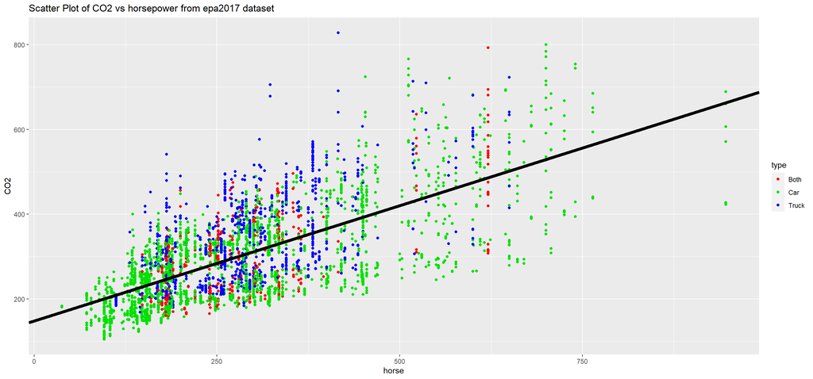

```r
g1 + geom_abline(slope = coef(m_co2_horse)[2], intercept = coef(m_co2_horse)[1], size=2)
```

Looking at the line and the distribution of the dots we see that more trucks seems to be above the line than below, and more cars seem to be below the line than above.

- Give an estimate for the average change in `CO2` for a one foot-pound per second increase in `horse` for a vehicle of type `car`.

```r
coef(m_co2_horse)[2]
```

```
##  horse
## 0.5436
```

- Give a 90% prediction interval using this model for the `CO2` of a Subaru Impreza Wagon, which is a vehicle with 148 horsepower and is considered type `Both`. (Interestingly, the dataset gives the wrong drivetrain for most Subarus in this dataset, as they are almost all listed as `F`, when they are in fact all-wheel drive.)

```r
# It doesnt matter if we use type in newdata or skip it completely. Since type is not part of our model, it will not make a difference
newdata <- data.frame(horse=c(148), type=c("Both"))
predict(m_co2_horse, newdata = newdata, interval = c("prediction"), level = .9)
```

```
##     fit  lwr upr
## 1 228.8 91.5 366
```

Note: It doesnt matter if we use type in newdata or skip it completely. Since type is not part of our model, it will not make a difference. It is being included since the question mentions it

**(b)** Do the following:

- Make a scatterplot of `CO2` versus `horse`. Use a different color point for each vehicle `type`.

```r
g2 <- ggplot(data=epa_df, aes(x=horse, y= CO2, group=type, col=type)) + geom_point() + ggtitle("Scatter Plot of CO2 vs horsepower from epa2017 dataset")  + scale_color_hue(c=400)
g2
```

- Fit an additive multiple regression model with `CO2` as the response and `horse` and `type` as the predictors.

```r
# creating model without reference level
m_co2_horse_type_add_param <- lm(formula = CO2~0 + type + horse, data = epa_df)
```

- Add the fitted regression “lines” to the scatterplot with the same colors as their respective points (one line for each vehicle type). Comment on how well this line models the data.

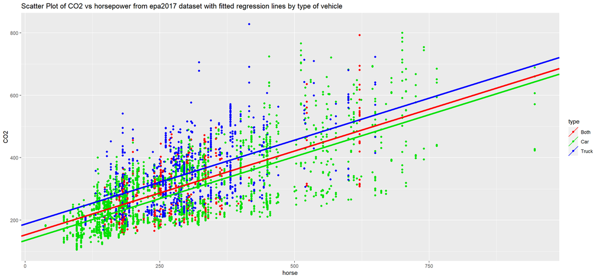

```r
g2 +
  geom_abline(aes(intercept = coef(m_co2_horse_type_add_param)[1], slope = coef(m_co2_horse_type_add_param)[4], color='Both', size=I(1.5))) +
  geom_abline(aes(intercept = coef(m_co2_horse_type_add_param)[2], slope = coef(m_co2_horse_type_add_param)[4], color='Car', size=I(1.5)))  +
  geom_abline(aes(intercept = coef(m_co2_horse_type_add_param)[3], slope = coef(m_co2_horse_type_add_param)[4], color='Truck', size=I(1.5))) + ggtitle("Scatter Plot of CO2 vs horsepower from epa2017 dataset with fitted regression lines by type of vehicle")
```

The lines seem to fit the model well and much better than a line with a single intercept but we still see that for cars and trucks the lines dont seem to fit the points perfectly

- Give an estimate for the average change in `CO2` for a one foot-pound per second increase in `horse` for a vehicle of type `car`.

```r
coef(m_co2_horse_type_add_param)[4]
```

```
##  horse
## 0.5372
```

- Give a 90% prediction interval using this model for the `CO2` of a Subaru Impreza Wagon, which is a vehicle with 148 horsepower and is considered type `Both`.

```r
newdata <- data.frame(horse=c(148), type=c("Both"))
predict(m_co2_horse_type_add_param, newdata = newdata, interval = c("prediction"), level = .9)
```

```
##     fit lwr   upr
## 1 232.4 100 364.9
```

**(c)** Do the following:

- Make a scatterplot of `CO2` versus `horse`. Use a different color point for each vehicle `type`.

```r
g3 <- ggplot(data=epa_df, aes(x=horse, y= CO2, group=type, col=type)) + geom_point() + ggtitle("Scatter Plot of CO2 vs horsepower from epa2017 dataset") + scale_color_hue(c=400)
g3
```

- Fit an interaction multiple regression model with `CO2` as the response and `horse` and `type` as the predictors.

```r
# creating model without reference level
m_co2_horse_type_int_param <- lm(formula = CO2~0 + type + horse:type, data = epa_df)
```

- Add the fitted regression “lines” to the scatterplot with the same colors as their respective points (one line for each vehicle type). Comment on how well this line models the data.

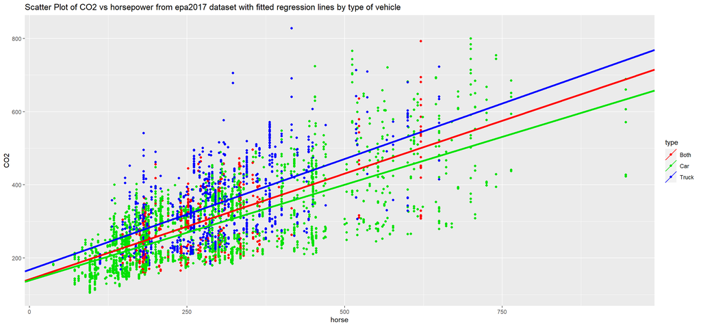

```r
g3 +
  geom_abline(aes(intercept = coef(m_co2_horse_type_int_param)[1], slope = coef(m_co2_horse_type_int_param)[4], color='Both', size=I(1.5))) +
  geom_abline(aes(intercept = coef(m_co2_horse_type_int_param)[2], slope = coef(m_co2_horse_type_int_param)[5], color='Car', size=I(1.5)))  +
  geom_abline(aes(intercept = coef(m_co2_horse_type_int_param)[3], slope = coef(m_co2_horse_type_int_param)[6], color='Truck', size=I(1.5))) + ggtitle("Scatter Plot of CO2 vs horsepower from epa2017 dataset with fitted regression lines by type of vehicle")
```

We see that these lines seem to fit better for cars and trucks

- Give an estimate for the average change in `CO2` for a one foot-pound per second increase in `horse` for a vehicle of type `car`.

```r
coef(m_co2_horse_type_int_param)[5]
```

```
## typeCar:horse
##        0.5226
```

- Give a 90% prediction interval using this model for the `CO2` of a Subaru Impreza Wagon, which is a vehicle with 148 horsepower and is considered type `Both`.

```r
newdata <- data.frame(horse=c(148), type=c("Both"))
predict(m_co2_horse_type_int_param, newdata = newdata, interval = c("prediction"), level = .9)
```

```
##     fit   lwr upr
## 1 227.5 95.01 360
```

**(d)** Based on the previous plots, you probably already have an opinion on the best model. Now use an ANOVA $F$-test to compare the additive and interaction models. Based on this test and a significance level of $\alpha = 0.10$, which model is preferred?

```r
anova(m_co2_horse_type_add_param,m_co2_horse_type_int_param)$`Pr(>F)`[2]
```

```
## [1] 0.005899
```

Since the probability is less than $\alpha$, we prefer the interactive model

## Exercise 2 (Hospital SUPPORT Data, White Blood Cells)

For this exercise, we will use the data stored in `hospital.csv`. It contains a random sample of 580 seriously ill hospitalized patients from a famous study called “SUPPORT” (Study to Understand Prognoses Preferences Outcomes and Risks of Treatment). As the name suggests, the purpose of the study was to determine what factors affected or predicted outcomes, such as how long a patient remained in the hospital. The variables in the dataset are:

- `Days` - Days to death or hospital discharge
- `Age` - Age on day of hospital admission
- `Sex` - Female or male
- `Comorbidity` - Patient diagnosed with more than one chronic disease
- `EdYears` - Years of education
- `Education` - Education level; high or low
- `Income` - Income level; high or low
- `Charges` - Hospital charges, in dollars
- `Care` - Level of care required; high or low
- `Race` - Non-white or white
- `Pressure` - Blood pressure, in mmHg
- `Blood` - White blood cell count, in gm/dL
- `Rate` - Heart rate, in bpm

For this exercise, we will use `Age`, `Education`, `Income`, and `Sex` in an attempt to model `Blood`. Essentially, we are attempting to model white blood cell count using only demographic information.

**(a)** Load the data, and check its structure using `str()`. Verify that `Education`, `Income`, and `Sex` are factors; if not, coerce them to be factors. What are the levels of `Education`, `Income`, and `Sex`?

```r
hsp_df <- read.csv("hospital.csv")
print("Structure of dataset before coercing type is below ")
str(hsp_df)

hsp_df$Education <- as.factor(hsp_df$Education)
hsp_df$Income <- as.factor(hsp_df$Income)
hsp_df$Sex <- as.factor(hsp_df$Sex)

print("Structure of dataset after coercing type of Education, Income and sex to factor is below ")
str(hsp_df)
```

```
## [1] "Structure of dataset before coercing type is below "
## 'data.frame':    580 obs. of  13 variables:
##  $ Days       : int  8 14 21 4 11 9 25 26 9 16 ...
##  $ Age        : num  42.3 63.7 41.5 42 52.1 ...
##  $ Sex        : chr  "female" "female" "male" "male" ...
##  $ Comorbidity: chr  "no" "no" "yes" "yes" ...
##  $ EdYears    : int  11 22 18 16 8 12 12 13 16 30 ...
##  $ Education  : chr  "low" "high" "high" "high" ...
##  $ Income     : chr  "high" "high" "high" "high" ...
##  $ Charges    : num  9914 283303 320843 4173 13414 ...
##  $ Care       : chr  "low" "high" "high" "low" ...
##  $ Race       : chr  "non-white" "white" "white" "white" ...
##  $ Pressure   : int  84 69 66 97 89 57 99 115 93 102 ...
##  $ Blood      : num  11.3 30.1 0.2 10.8 6.4 ...
##  $ Rate       : int  94 108 130 88 92 114 150 132 86 90 ...
## [1] "Structure of dataset after coercing type of Education, Income and sex to factor is below "
## 'data.frame':    580 obs. of  13 variables:
##  $ Days       : int  8 14 21 4 11 9 25 26 9 16 ...
##  $ Age        : num  42.3 63.7 41.5 42 52.1 ...
##  $ Sex        : Factor w/ 2 levels "female","male": 1 1 2 2 2 2 1 1 2 2 ...
##  $ Comorbidity: chr  "no" "no" "yes" "yes" ...
##  $ EdYears    : int  11 22 18 16 8 12 12 13 16 30 ...
##  $ Education  : Factor w/ 2 levels "high","low": 2 1 1 1 2 2 2 1 1 1 ...
##  $ Income     : Factor w/ 2 levels "high","low": 1 1 1 1 1 1 2 1 1 1 ...
##  $ Charges    : num  9914 283303 320843 4173 13414 ...
##  $ Care       : chr  "low" "high" "high" "low" ...
##  $ Race       : chr  "non-white" "white" "white" "white" ...
##  $ Pressure   : int  84 69 66 97 89 57 99 115 93 102 ...
##  $ Blood      : num  11.3 30.1 0.2 10.8 6.4 ...
##  $ Rate       : int  94 108 130 88 92 114 150 132 86 90 ...
```

**(b)** Fit an additive multiple regression model with `Blood` as the response using `Age`, `Education`, `Income`, and `Sex` as predictors. What does `R` choose as the reference level for `Education`, `Income`, and `Sex`?

```r
m_hsp_add <- lm(formula = Blood~Age+Education+Income+Sex, data=hsp_df)
coef(m_hsp_add)
```

```
##  (Intercept)          Age Educationlow    Incomelow      Sexmale
##     10.86624      0.02828      0.59667      0.18667     -1.87144
```

R chooses high for Education and Income as reference and female for Sex as reference. R does this since alphabetically high comes before low and female comes before male

**(c)** Fit a multiple regression model with `Blood` as the response. Use the main effects of `Age`, `Education`, `Income`, and `Sex`, as well as the interaction of `Sex` with `Age` and the interaction of `Sex` and `Income`. Use a statistical test to compare this model to the additive model using a significance level of $\alpha = 0.10$. Which do you prefer?

```r
m_hsp_int_2 <- lm(Blood~Age + Education + Income + Sex + Sex*Age + Sex*Income, data = hsp_df)
anova(m_hsp_add, m_hsp_int_2)$`Pr(>F)`[2]
```

```
## [1] 0.1128
```

Since p-value is greater than $\alpha$ we prefer the additive model

**(d)** Fit a model similar to that in **(c)**, but additionally add the interaction between `Income` and `Age` as well as a three-way interaction between `Age`, `Income`, and `Sex`. Use a statistical test to compare this model to the preferred model from **(c)** using a significance level of $\alpha = 0.10$. Which do you prefer?

```r
m_hsp_int_3 <- lm(Blood~Education + Sex*Age*Income, data = hsp_df)
anova(m_hsp_add, m_hsp_int_3)$`Pr(>F)`[2]
```

```
## [1] 0.07439
```

Since the p-value is less than $\alpha$ we prefer the three way interaction model

**(e)** Using the model in **(d)**, give an estimate of the change in average `Blood` for a one-unit increase in `Age` for a highly educated, low income, male patient.

```r
coef(m_hsp_int_3)[3+1] + coef(m_hsp_int_3)[5+1] + coef(m_hsp_int_3)[7+1] + coef(m_hsp_int_3)[8+1]
```

```
##    Age
## 0.0053
```

## Exercise 3 (Hospital SUPPORT Data, Stay Duration)

For this exercise, we will again use the data stored in `hospital.csv`. It contains a random sample of 580 seriously ill hospitalized patients from a famous study called “SUPPORT” (Study to Understand Prognoses Preferences Outcomes and Risks of Treatment). As the name suggests, the purpose of the study was to determine what factors affected or predicted outcomes, such as how long a patient remained in the hospital. The variables in the dataset are:

- `Days` - Days to death or hospital discharge
- `Age` - Age on day of hospital admission
- `Sex` - Female or male
- `Comorbidity` - Patient diagnosed with more than one chronic disease
- `EdYears` - Years of education
- `Education` - Education level; high or low
- `Income` - Income level; high or low
- `Charges` - Hospital charges, in dollars
- `Care` - Level of care required; high or low
- `Race` - Non-white or white
- `Pressure` - Blood pressure, in mmHg
- `Blood` - White blood cell count, in gm/dL
- `Rate` - Heart rate, in bpm

For this exercise, we will use `Blood`, `Pressure`, and `Rate` in an attempt to model `Days`. Essentially, we are attempting to model the time spent in the hospital using only health metrics measured at the hospital.

Consider the model

$$Y = \beta_0 + \beta_1 x_1 + \beta_2 x_2 + \beta_3 x_3 + \beta_4 x_1 x_2 + \beta_5 x_1 x_3 + \beta_6 x_2 x_3 + \beta_7 x_1 x_2 x_3 + \epsilon,$$

where

- $Y$ is `Days`
- $x_1$ is `Blood`
- $x_2$ is `Pressure`
- $x_3$ is `Rate`.

**(a)** Fit the model above. Also fit a smaller model using the provided `R` code.

```r
days_add <- lm(Days ~ Pressure + Blood + Rate, data = hsp_df)
days_int <- lm(Days~Blood*Pressure*Rate, data = hsp_df)
```

Use a statistical test to compare the two models. Report the following:

```r
(anova_test <- anova(days_add, days_int))
```

```
## Analysis of Variance Table
##
## Model 1: Days ~ Pressure + Blood + Rate
## Model 2: Days ~ Blood * Pressure * Rate
##   Res.Df    RSS Df Sum of Sq    F Pr(>F)
## 1    576 279493
## 2    572 275557  4      3936 2.04  0.087 .
## ---
## Signif. codes:  0 '***' 0.001 '**' 0.01 '*' 0.05 '.' 0.1 ' ' 1
```

- The null and alternative hypotheses in terms of the model given in the exercise description

The Null Hypothesis is defined as $H_0 : \beta_4 = \beta_5 = \beta_6 = \beta_7 = 0$ or there are no interactions between Pressure, Blood and Rate.

The Alternate Hypothesis is defined as $\text{at least one or more of } \beta_4, \beta_5, \beta_6, \beta_7 \neq 0$ or there is interaction between some or all of Blood, Rate, Pressure.

- The value of the test statistic

```r
anova_test$F[2]
```

```
## [1] 2.043
```

- The p-value of the test

```r
anova_test$`Pr(>F)`[2]
```

```
## [1] 0.08705
```

- A statistical decision using a significance level of $\alpha = 0.10$

Since the p-value is less than $\alpha$, we reject the Null Hypothesis $H_0$ and accept the alternate Hypothesis that there is significance of interaction between some or all of Blood, Rate and Pressure.

- Which model you prefer

We prefer the interactive model or the full model given in the problem statement

**(b)** Give an expression based on the model in the exercise description for the true change in length of hospital stay in days for a 1 bpm increase in `Rate` for a patient with a `Pressure` of 139 mmHg and a `Blood` of 10 gm/dL. Your answer should be a linear function of the $\beta$s.

In order to calculate the expression we will subtract the model with the values above and Rate = 2 from the model again with the values above and Rate = 1. This will result in all expressions except the one which has Rate (x3) to cancel out. Seeing this in an equation we say

$Days_{rate=2} - Days_{rate=1}$

Where

$Days_{rate=1} = \beta_0 + 10\beta_1 + 139\beta_2 + 1\beta_3 + 1390\beta_4 + 10\beta_5 + 139\beta_6 + 1390\beta_7 + \epsilon$

$Days_{rate=2} = \beta_0 + 10\beta_1 + 139\beta_2 + 2\beta_3 + 1390\beta_4 + 10*2\beta_5 + 139*2\beta_6 + 1390*2\beta_7 + \epsilon$

Now subtracting the above two expressions we get

$Days_{\text{Increase due to Rate increase of 1}} = \beta_3 + 10\beta_5 + 139\beta_6 + 1390\beta_7$

**(c)** Give an expression based on the additive model in part **(a)** for the true change in length of hospital stay in days for a 1 bpm increase in `Rate` for a patient with a `Pressure` of 139 mmHg and a `Blood` of 10 gm/dL. Your answer should be a linear function of the $\beta$s.

In order to calculate the expression we will subtract the additive model with the values above and Rate = 2 from the additive model again with the values above and Rate = 1. This will result in all expressions except the one which has Rate (x3) to cancel out. Seeing this in an equation we say

$Days_{rate=2} - Days_{rate=1}$

Where

$Days_{rate=1} = \beta_0 + 10\beta_1 + 139\beta_2 + 1\beta_3 + \epsilon$

$Days_{rate=2} = \beta_0 + 10\beta_1 + 139\beta_2 + 2\beta_3 + \epsilon$

Now subtracting the above two expressions we get

$Days_{\text{Increase due to Rate increase of 1}} = \beta_3$

## Exercise 4 ($t$-test Is a Linear Model)

In this exercise, we will try to convince ourselves that a two-sample $t$-test assuming equal variance is the same as a $t$-test for the coefficient in front of a single two-level factor variable (dummy variable) in a linear model.

First, we set up the data frame that we will use throughout.

```r
n = 30

sim_data = data.frame(
  groups = c(rep("A", n / 2), rep("B", n / 2)),
  values = rep(0, n))
str(sim_data)
```

```
## 'data.frame':    30 obs. of  2 variables:
##  $ groups: chr  "A" "A" "A" "A" ...
##  $ values: num  0 0 0 0 0 0 0 0 0 0 ...
```

We will use a total sample size of `30`, `15` for each group. The `groups` variable splits the data into two groups, `A` and `B`, which will be the grouping variable for the $t$-test and a factor variable in a regression. The `values` variable will store simulated data.

We will repeat the following process a number of times.

```r
set.seed(20)
sim_data$values = rnorm(n, mean = 42, sd = 3.5) # simulate response data
summary(lm(values ~ groups, data = sim_data))
```

```
##
## Call:
## lm(formula = values ~ groups, data = sim_data)
##
## Residuals:
##    Min     1Q Median     3Q    Max
##  -9.04  -1.11  -0.14   2.23   7.33
##
## Coefficients:
##             Estimate Std. Error t value Pr(>|t|)
## (Intercept)   40.922      0.950   43.07   <2e-16 ***
## groupsB        0.029      1.344    0.02     0.98
## ---
## Signif. codes:  0 '***' 0.001 '**' 0.01 '*' 0.05 '.' 0.1 ' ' 1
##
## Residual standard error: 3.68 on 28 degrees of freedom
## Multiple R-squared:  1.66e-05,   Adjusted R-squared:  -0.0357
## F-statistic: 0.000465 on 1 and 28 DF,  p-value: 0.983
```

```r
t.test(values ~ groups, data = sim_data, var.equal = TRUE)
```

```
##
##  Two Sample t-test
##
## data:  values by groups
## t = -0.022, df = 28, p-value = 1
## alternative hypothesis: true difference in means is not equal to 0
## 95 percent confidence interval:
##  -2.781  2.723
## sample estimates:
## mean in group A mean in group B
##           40.92           40.95
```

We use `lm()` to test

$$H_0: \beta_1 = 0$$

for the model

$$Y = \beta_0 + \beta_1 x_1 + \epsilon$$

where $Y$ is the values of interest, and $x_1$ is a dummy variable that splits the data in two. We will let `R` take care of the dummy variable.

We use `t.test()` to test

$$H_0: \mu_A = \mu_B$$

where $\mu_A$ is the mean for the `A` group, and $\mu_B$ is the mean for the `B` group.

The following code sets up some variables for storage.

```r
num_sims = 300
lm_t = rep(0, num_sims)
lm_p = rep(0, num_sims)
tt_t = rep(0, num_sims)
tt_p = rep(0, num_sims)
```

- `lm_t` will store the test statistic for the test $H_0: \beta_1 = 0$.
- `lm_p` will store the p-value for the test $H_0: \beta_1 = 0$.
- `tt_t` will store the test statistic for the test $H_0: \mu_A = \mu_B$.
- `tt_p` will store the p-value for the test $H_0: \mu_A = \mu_B$.

The variable `num_sims` controls how many times we will repeat this process, which we have chosen to be `300`.

**(a)** Set a seed equal to your birthday. Then write code that repeats the above process `300` times. Each time, store the appropriate values in `lm_t`, `lm_p`, `tt_t`, and `tt_p`. Specifically, each time you should use `sim_data$values = rnorm(n, mean = 42, sd = 3.5)` to update the data. The grouping will always stay the same.

```r
set.seed(19732103)

for (i in 1:num_sims){
  sim_data$values = rnorm(n, mean = 42, sd = 3.5) # simulate response data

  m <- lm(values ~ groups, data = sim_data)
  lm_t[i] <- coef(summary(m))["groupsB", "t value"]
  lm_p[i] <- coef(summary(m))["groupsB", "Pr(>|t|)"]
  t_test <- t.test(values ~ groups, data = sim_data, var.equal = TRUE)
  tt_t[i] <- t_test$statistic
  tt_p[i] <- t_test$p.value
}
```

**(b)** Report the value obtained by running `mean(lm_t == tt_t)`, which tells us what proportion of the test statistics is equal. The result may be extremely surprising!

```r
mean(lm_t == tt_t)
```

```
## [1] 0
```

**(c)** Report the value obtained by running `mean(lm_p == tt_p)`, which tells us what proportion of the p-values is equal. The result may be extremely surprising!

```r
mean(lm_p == tt_p)
```

```
## [1] 0.02667
```

**(d)** If you have done everything correctly so far, your answers to the last two parts won’t indicate the equivalence we want to show! What the heck is going on here? The first issue is one of using a computer to do calculations. When a computer checks for equality, it demands **equality**; nothing can be different. However, when a computer performs calculations, it can only do so with a certain level of precision. So, if we calculate two quantities we know to be analytically equal, they can differ numerically. Instead of `mean(lm_p == tt_p)` run `all.equal(lm_p, tt_p)`. This will perform a similar calculation, but with a very small error tolerance for each equality. What is the result of running this code? What does it mean?

```r
all.equal(lm_p, tt_p)
```

```
## [1] TRUE
```

**(e)** Your answer in **(d)** should now make much more sense. Then what is going on with the test statistics? Look at the values stored in `lm_t` and `tt_t`. What do you notice? Is there a relationship between the two? Can you explain why this is happening?

```r
head(lm_t, 10)
```

```
##  [1]  1.5245 -1.9912  1.4530 -0.4572  0.9823 -1.1067  0.7210  0.4945  2.8495
## [10] -1.2787
```

```r
head(tt_t, 10)
```

```
##  [1] -1.5245  1.9912 -1.4530  0.4572 -0.9823  1.1067 -0.7210 -0.4945 -2.8495
## [10]  1.2787
```

We notice that while the absolute values are same across lm_t and tt_t, they are negative of each other.This could be because R is picking the reference level which is different than the t-test and that is causing the t statistic value to be reversed